# TMDB Analysis

## Members

Islam Mohamed 171549 Mostafa Yasser 170397 Youssef Tarek 178112

## Introduction

### Dataset

The data set contains information about 10,000 movies collected from The Movie Database (TMDb), including user ratings and revenue.

The columns selected for the context of this report are: “id”, “popularity”,“budget”,“revenue”,“cast”,“genres”

### Questions:

1. What are the most popular genres?
2. What is the average movie budget for each genre?
3. What is the average movie revenue for each genre?
4. How the cast influence the revenue?
5. How much impact does popularity has on revenue?

## Data Reading and Processing

### Imports

```r
library(ggplot2)
library(dplyr)
```

### Read the dataset

```r
 all_movies <- read.csv("./Datasets/tmdb-movies.csv")
```

```r
all_movies[0:3,]
```

|  | id | imdb_id | popularity | budget | revenue | original_title | cast | homepage | director | tagline | keywords | overview | runtime | genres | production_companies | release_date | vote_count | vote_average | release_year | budget_adj | revenue_adj |
| --- | --- | --- | --- | --- | --- | --- | --- | --- | --- | --- | --- | --- | --- | --- | --- | --- | --- | --- | --- | --- | --- |
| 1 | 135397 | tt0369610 | 32.98576 | 150000000 | 1513528810 | Jurassic World | Chris Pratt\|Bryce Dallas Howard\|Irrfan Khan\|Vincent D'Onofrio\|Nick Robinson | http://www.jurassicworld.com/ | Colin Trevorrow | The park is open. | monster\|dna\|tyrannosaurus rex\|velociraptor\|island | Twenty-two years after the events of Jurassic Park, Isla Nublar now features a fully functioning dinosaur theme park, Jurassic World, as originally envisioned by John Hammond. | 124 | Action\|Adventure\|Science Fiction\|Thriller | Universal Studios\|Amblin Entertainment\|Legendary Pictures\|Fuji Television Network\|Dentsu | 6/9/15 | 5562 | 6.5 | 2015 | 137999939 | 1392445893 |
| 2 | 76341 | tt1392190 | 28.41994 | 150000000 | 378436354 | Mad Max: Fury Road | Tom Hardy\|Charlize Theron\|Hugh Keays-Byrne\|Nicholas Hoult\|Josh Helman | http://www.madmaxmovie.com/ | George Miller | What a Lovely Day. | future\|chase\|post-apocalyptic\|dystopia\|australia | An apocalyptic story set in the furthest reaches of our planet, in a stark desert landscape where humanity is broken, and most everyone is crazed fighting for the necessities of life. Within this worl… | 120 | Action\|Adventure\|Science Fiction\|Thriller | Village Roadshow Pictures\|Kennedy Miller Productions | 5/13/15 | 6185 | 7.1 | 2015 | 137999939 | 348161292 |
| 3 | 262500 | tt2908446 | 13.11251 | 110000000 | 295238201 | Insurgent | Shailene Woodley\|Theo James\|Kate Winslet\|Ansel Elgort\|Miles Teller | http://www.thedivergentseries.movie/#insurgent | Robert Schwentke | One Choice Can Destroy You | based on novel\|revolution\|dystopia\|sequel\|dystopic future | Beatrice Prior must confront her inner demons and continue her fight against a powerful alliance which threatens to tear her society apart. | 119 | Adventure\|Science Fiction\|Thriller | Summit Entertainment\|Mandeville Films\|Red Wagon Entertainment\|NeoReel | 3/18/15 | 2480 | 6.3 | 2015 | 101199955 | 271619025 |

### remove unncessary columns

```r
all_movies = all_movies[,!(names(all_movies) %in% c('imdb_id','homepage','director','overview','tagline','keywords','budget_adj','revenue_adj','production_companies','original_title'))]
all_movies[1,]
```

|  | id | popularity | budget | revenue | cast | runtime | genres | release_date | vote_count | vote_average | release_year |
| --- | --- | --- | --- | --- | --- | --- | --- | --- | --- | --- | --- |
| 1 | 135397 | 32.98576 | 150000000 | 1513528810 | Chris Pratt\|Bryce Dallas Howard\|Irrfan Khan\|Vincent D'Onofrio\|Nick Robinson | 124 | Action\|Adventure\|Science Fiction\|Thriller | 6/9/15 | 5562 | 6.5 | 2015 |

### remove NA rows

```r
nrow(all_movies)
```

```
[1] 10866
```

```r
all_movies = all_movies[rowSums(is.na(all_movies)) == 0,]
nrow(all_movies)
```

```
[1] 10866
```

### genres to vector

The genres are formatted as a string with a seperator. e.g., `action|drama`. The genres will be transformed to a vector for better access

```r
all_movies$genres = strsplit(all_movies$genres, "\\|")
```

### spread genres

Each row containing several genres will be repeated to be one genre per row

```r
movies_genres = all_movies %>%
  unnest(genres)
```

## EDA

### data summary

```r
#summary(all_movies)
summary(movies_genres)
```

```
       id           popularity           budget             revenue              cast              runtime         genres          release_date         vote_count
 Min.   :     5   Min.   : 0.00006   Min.   :        0   Min.   :0.000e+00   Length:26960       Min.   :  0.0   Length:26960       Length:26960       Min.   :  10
 1st Qu.: 10201   1st Qu.: 0.22463   1st Qu.:        0   1st Qu.:0.000e+00   Class :character   1st Qu.: 90.0   Class :character   Class :character   1st Qu.:  18
 Median : 18214   Median : 0.41142   Median :      113   Median :0.000e+00   Mode  :character   Median : 99.0   Mode  :character   Mode  :character   Median :  44
 Mean   : 58678   Mean   : 0.70609   Mean   : 17510130   Mean   :4.744e+07                      Mean   :102.8                                         Mean   : 250
 3rd Qu.: 58236   3rd Qu.: 0.77474   3rd Qu.: 20000000   3rd Qu.:3.054e+07                      3rd Qu.:112.0                                         3rd Qu.: 173
 Max.   :417859   Max.   :32.98576   Max.   :425000000   Max.   :2.782e+09                      Max.   :900.0                                         Max.   :9767
  vote_average    release_year
 Min.   :1.500   Min.   :1960
 1st Qu.:5.400   1st Qu.:1994
 Median :6.000   Median :2005
 Mean   :5.956   Mean   :2001
 3rd Qu.:6.600   3rd Qu.:2011
 Max.   :9.200   Max.   :2015
```

### 1. What are the most used genres in movies?

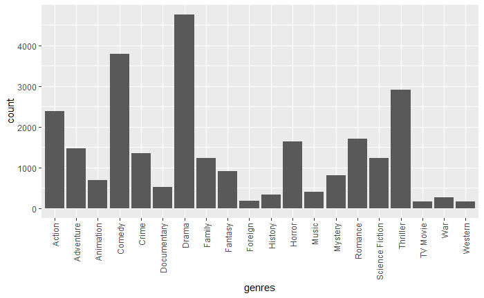

```r
ggplot(movies_genres, aes(genres)) + geom_bar(stat = 'count') + theme(axis.text.x = element_text(angle = 90, vjust = 0.5, hjust=1))
```

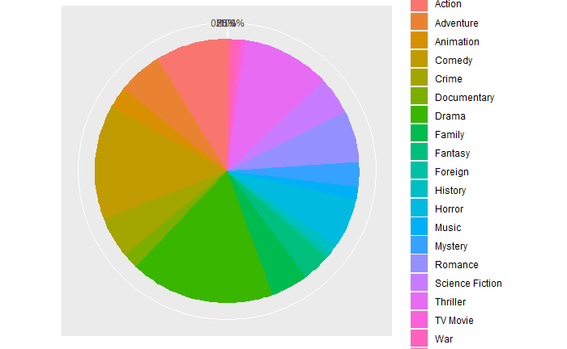

```r
ggplot(movies_genres,
        aes(x = factor(1),fill = factor(genres))) +
  geom_bar(stat = "count") +
  scale_y_continuous(breaks = seq(0,12,3), labels = c("0", "25%", "50%", "75%", "100%")) +
  coord_polar(theta='y') +
  theme(axis.text.y = element_blank(),
        axis.title.y = element_blank(),
        axis.ticks.y = element_blank(),
        axis.title.x = element_blank())
```

The most used genres are Drama, Comedy, Thriller, and Action. While TV movie, War, Western, and Foreign are lightly produced.

### 2. What is the average movie budget for each genre?

```r
budget_per_genre = aggregate(list(budget=movies_genres$budget), by=list(genre=movies_genres$genres), FUN=mean)
budget_per_genre
```

| genre | budget |
| --- | --- |
| Action | 27728773.0 |
| Adventure | 37543694.5 |
| Animation | 23159781.6 |
| Comedy | 13297915.6 |
| Crime | 17672905.3 |
| Documentary | 577149.1 |
| Drama | 11884523.5 |
| Family | 23359337.4 |
| Fantasy | 32612585.3 |
| Foreign | 1451434.9 |

[output cut: 10 more lines]

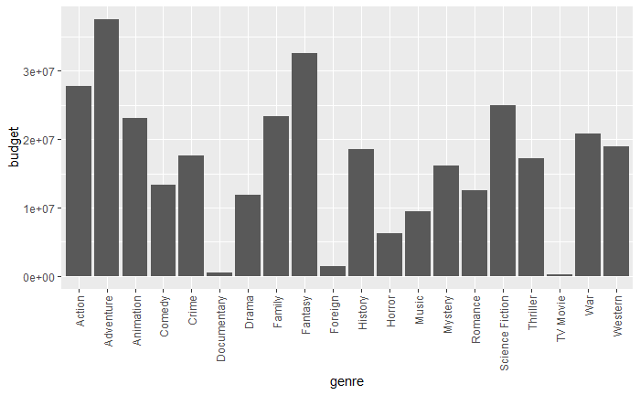

```r
ggplot(budget_per_genre, aes(genre, budget), label=as.character(round(x,2))) + geom_col() + theme(axis.text.x = element_text(angle = 90, vjust = 0.5, hjust=1))
```

### 3. What is the average movie revenue for each genre?

```r
revenue_per_genre = aggregate(list(revenue=movies_genres$revenue), by=list(genre=movies_genres$genres), FUN=mean)
revenue_per_genre[order(revenue_per_genre$revenue, decreasing = TRUE),]
```

|  | genre | revenue |
| --- | --- | --- |
| 2 | Adventure | 113137861 |
| 9 | Fantasy | 96313657 |
| 3 | Animation | 75256062 |
| 1 | Action | 72764616 |
| 8 | Family | 72433176 |
| 16 | Science Fiction | 70084319 |
| 19 | War | 47605183 |
| 5 | Crime | 42338107 |
| 17 | Thriller | 41714401 |
| 14 | Mystery | 40217567 |

[output cut: 10 more lines]

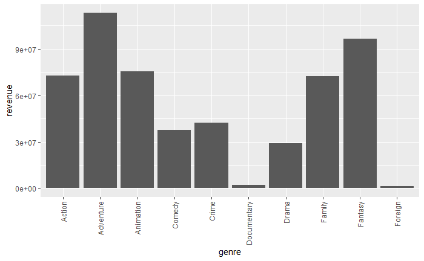

```r
ggplot(revenue_per_genre[1:10,], aes(genre, revenue), label=as.character(round(x,2))) + geom_col() + theme(axis.text.x = element_text(angle = 90, vjust = 0.5, hjust=1))
```

### 4. How the cast influence the revenue?

Top 30 influence

```r
movies_cast = all_movies %>%
  mutate(cast=strsplit(cast, "\\|")) %>%
  unnest(cast)
```

```r
revenue_per_cast = aggregate(movies_cast$revenue, by=list(cast=movies_cast$cast), FUN=mean)
revenue_per_cast = revenue_per_cast[order(revenue_per_cast$x, decreasing = TRUE),]
revenue_per_cast
```

|  | cast | x |
| --- | --- | --- |
| 3919 | Daisy Ridley | 2068178225 |
| 16159 | Santino Fontana | 1274219009 |
| 2152 | Bob Peck | 920100000 |
| 15428 | Robert MacNaughton | 792910554 |
| 15750 | Rosemary Harris | 783766341 |
| 15077 | Richard Armitage | 772781388 |
| 7432 | Isobelle Molloy | 758410378 |
| 7069 | Helmut Bakaitis | 738599701 |
| 14533 | Phaldut Sharma | 716392705 |
| 14947 | Rebecca Ferguson | 682330139 |

[output cut: 990 more lines]

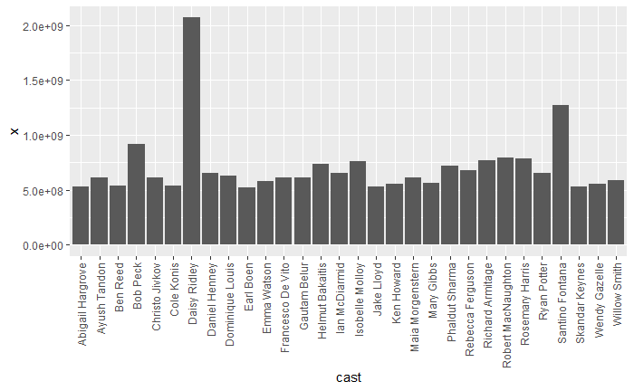

```r
ggplot(revenue_per_cast[1:30,], aes(cast, x)) + geom_col() + theme(axis.text.x = element_text(angle = 90, vjust = 0.5, hjust=1))
```

### 5. How much impact does popularity has on revenue?

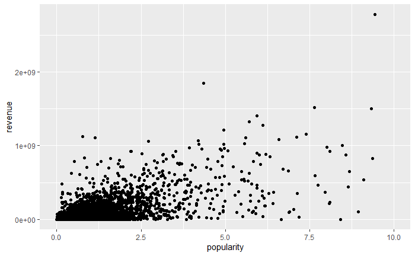

```r
ggplot(all_movies, aes(popularity, revenue)) + geom_point() + xlim(0, 10)
```

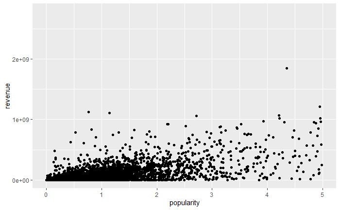

```r
ggplot(all_movies, aes(popularity, revenue)) + geom_point() + xlim(0, 5)
```

The popularity of a movie has an effect on the revenue.

## Linear Regression

```r
regression_model = lm(data = all_movies, formula = revenue ~ budget)
regression_model
```

```
Call:
lm(formula = revenue ~ budget, data = all_movies)

Coefficients:
(Intercept)       budget
 -8.585e+05    2.782e+00
```

```r
summary(regression_model)
```

```
Call:
lm(formula = revenue ~ budget, data = all_movies)

Residuals:
       Min         1Q     Median         3Q        Max
-1.170e+09 -9.367e+06  8.585e+05  8.585e+05  2.123e+09

Coefficients:
              Estimate Std. Error t value Pr(>|t|)
(Intercept) -8.585e+05  8.422e+05  -1.019    0.308
budget       2.782e+00  2.463e-02 112.949   <2e-16 ***
---
Signif. codes:  0 ‘***’ 0.001 ‘**’ 0.01 ‘*’ 0.05 ‘.’ 0.1 ‘ ’ 1

Residual standard error: 79350000 on 10864 degrees of freedom
Multiple R-squared:  0.5401,    Adjusted R-squared:   0.54
F-statistic: 1.276e+04 on 1 and 10864 DF,  p-value: < 2.2e-16
```

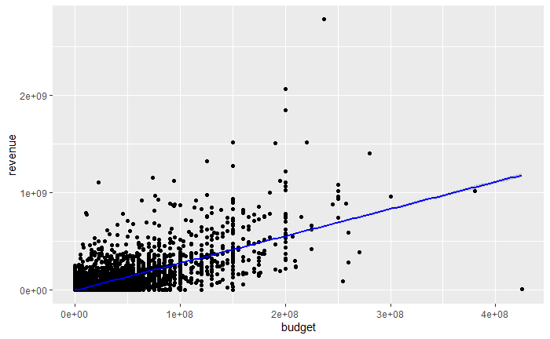

```r
ggplot(all_movies, aes(budget, revenue)) + geom_point() + geom_smooth(method = 'lm', col='blue')
```